# Customer Lifetime Value Prediction

Customer Lifetime Value represents a customer’s value to a company over a period of time. It’s a competitive market for insurance companies in 2019, and insurance premium isn’t the only determining factor in a customer’s decisions. CLV is a customer-centric metric, and a powerful base to build upon to retain valuable customers, increase revenue from less valuable customers, and improve the customer experience overall.

## Business Problem

An Auto Insurance company in the USA is facing issues in retaining its customers and wants to advertise promotional offers for its loyal customers. They are considering Customer Lifetime Value CLV as a parameter for this purpose. Customer Lifetime Value represents a customer’s value to a company over a period of time. It’s a competitive market for insurance companies, and the insurance premium isn’t the only determining factor in a customer’s decisions. CLV is a customer-centric metric, and a powerful base to build upon to retain valuable customers, increase revenue from less valuable customers, and improve the customer experience overall. Using CLV effectively can improve customer acquisition and customer retention, prevent churn, help the company to plan its marketing budget, measure the performance of their ads in more detail, and much more.

## Project Overview

- The objective of the problem is to accurately predict the Customer Lifetime Value(CLV) of the customer for an Auto Insurance Company

## Import libraries

```python
import pandas as pd
import numpy as np
import scipy.stats as stats
import seaborn as sns
import matplotlib.pyplot as plt
import statsmodels.api as sm
```

```python
df=pd.read_csv("Data/AutoInsurance.csv")
df.head()
```

|  | Customer | State | Customer Lifetime Value | Response | Coverage | Education | Effective To Date | EmploymentStatus | Gender | Income | ... | Months Since Policy Inception | Number of Open Complaints | Number of Policies | Policy Type | Policy | Renew Offer Type | Sales Channel | Total Claim Amount | Vehicle Class | Vehicle Size |
| --- | --- | --- | --- | --- | --- | --- | --- | --- | --- | --- | --- | --- | --- | --- | --- | --- | --- | --- | --- | --- | --- |
| 0 | BU79786 | Washington | 2763.519279 | No | Basic | Bachelor | 2/24/11 | Employed | F | 56274 | ... | 5 | 0 | 1 | Corporate Auto | Corporate L3 | Offer1 | Agent | 384.811147 | Two-Door Car | Medsize |
| 1 | QZ44356 | Arizona | 6979.535903 | No | Extended | Bachelor | 1/31/11 | Unemployed | F | 0 | ... | 42 | 0 | 8 | Personal Auto | Personal L3 | Offer3 | Agent | 1131.464935 | Four-Door Car | Medsize |
| 2 | AI49188 | Nevada | 12887.431650 | No | Premium | Bachelor | 2/19/11 | Employed | F | 48767 | ... | 38 | 0 | 2 | Personal Auto | Personal L3 | Offer1 | Agent | 566.472247 | Two-Door Car | Medsize |
| 3 | WW63253 | California | 7645.861827 | No | Basic | Bachelor | 1/20/11 | Unemployed | M | 0 | ... | 65 | 0 | 7 | Corporate Auto | Corporate L2 | Offer1 | Call Center | 529.881344 | SUV | Medsize |
| 4 | HB64268 | Washington | 2813.692575 | No | Basic | Bachelor | 3/2/2011 | Employed | M | 43836 | ... | 44 | 0 | 1 | Personal Auto | Personal L1 | Offer1 | Agent | 138.130879 | Four-Door Car | Medsize |

5 rows × 24 columns

```python
print("The number of rows:",df.shape[0])
print("The number of columns:",df.shape[1])
```

```
The number of rows: 9134
The number of columns: 24
```

```python
df.rename(columns={'Customer Lifetime Value':'CLV'},inplace=True)
```

```python
df.info()
```

```
<class 'pandas.core.frame.DataFrame'>
RangeIndex: 9134 entries, 0 to 9133
Data columns (total 24 columns):
 #   Column                         Non-Null Count  Dtype
---  ------                         --------------  -----
 0   Customer                       9134 non-null   object
 1   State                          9134 non-null   object
 2   CLV                            9134 non-null   float64
 3   Response                       9134 non-null   object
 4   Coverage                       9134 non-null   object
 5   Education                      9134 non-null   object
 6   Effective To Date              9134 non-null   object
 7   EmploymentStatus               9134 non-null   object
 8   Gender                         9134 non-null   object
 9   Income                         9134 non-null   int64
```

[output cut: 16 more lines]

```python
numerical_cols = df.select_dtypes(include=["int64","float64"])
```

```python
numerical_cols.columns
```

```
Index(['CLV', 'Income', 'Monthly Premium Auto', 'Months Since Last Claim',
       'Months Since Policy Inception', 'Number of Open Complaints',
       'Number of Policies', 'Total Claim Amount'],
      dtype='object')
```

```python
numerical_cols = numerical_cols.drop(["Number of Policies","Number of Open Complaints"],axis=1)
```

## Summary Statistics of Numerical features

```python
numerical_cols.describe()
```

|  | CLV | Income | Monthly Premium Auto | Months Since Last Claim | Months Since Policy Inception | Total Claim Amount |
| --- | --- | --- | --- | --- | --- | --- |
| count | 9134.000000 | 9134.000000 | 9134.000000 | 9134.000000 | 9134.000000 | 9134.000000 |
| mean | 8004.940475 | 37657.380009 | 93.219291 | 15.097000 | 48.064594 | 434.088794 |
| std | 6870.967608 | 30379.904734 | 34.407967 | 10.073257 | 27.905991 | 290.500092 |
| min | 1898.007675 | 0.000000 | 61.000000 | 0.000000 | 0.000000 | 0.099007 |
| 25% | 3994.251794 | 0.000000 | 68.000000 | 6.000000 | 24.000000 | 272.258244 |
| 50% | 5780.182197 | 33889.500000 | 83.000000 | 14.000000 | 48.000000 | 383.945434 |
| 75% | 8962.167041 | 62320.000000 | 109.000000 | 23.000000 | 71.000000 | 547.514839 |
| max | 83325.381190 | 99981.000000 | 298.000000 | 35.000000 | 99.000000 | 2893.239678 |

## Checking Null values

```python
df.isnull().sum()
```

```
Customer                         0
State                            0
CLV                              0
Response                         0
Coverage                         0
Education                        0
Effective To Date                0
EmploymentStatus                 0
Gender                           0
Income                           0
Location Code                    0
Marital Status                   0
Monthly Premium Auto             0
Months Since Last Claim          0
Months Since Policy Inception    0
Number of Open Complaints        0
Number of Policies               0
Policy Type                      0
Policy                           0
Renew Offer Type                 0
Sales Channel                    0
Total Claim Amount               0
Vehicle Class                    0
Vehicle Size                     0
dtype: int64
```

# EDA

## CLV - Target variable analysis

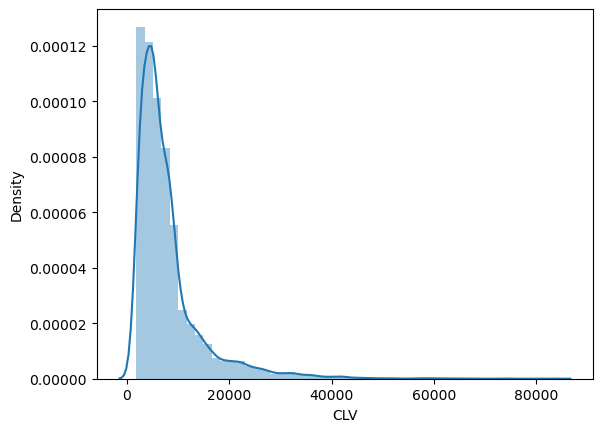

```python
sns.distplot(df["CLV"])
plt.show()
```

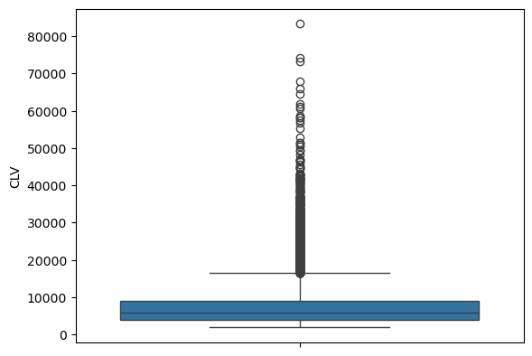

```python
sns.boxplot(df["CLV"])
plt.show()
```

```python
df["CLV"].skew()
```

```
3.0322802599299847
```

From the distribution and box plot we can infer that CLV is highly right skewed. There are lot of outliers in our dependent variable but we cant treat them directly because they are influential points.

## Income

### Univariate Analysis

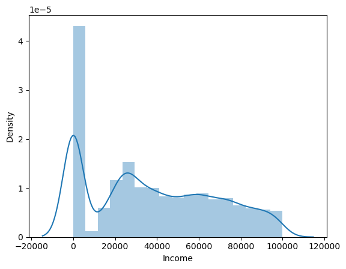

```python
sns.distplot(df["Income"])
plt.show()
```

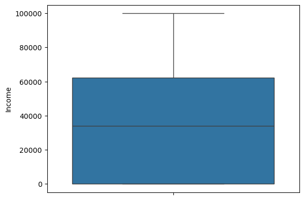

```python
sns.boxplot(df["Income"])
plt.show()
```

#### Bivariate Analysis

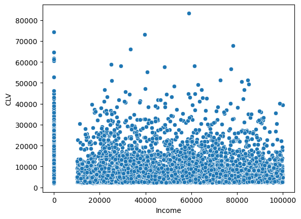

```python
sns.scatterplot(x=df["Income"], y=df["CLV"])
plt.show()
```

There is no linear relationship between income and CLV

### Monthly Premium Auto

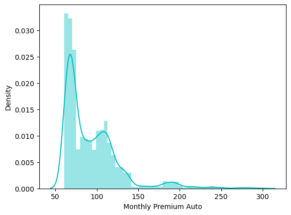

```python
sns.distplot(df["Monthly Premium Auto"],color='c')
plt.show()
```

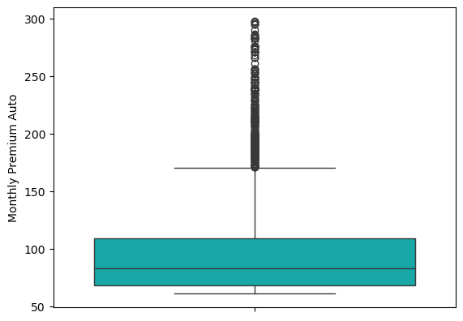

```python
sns.boxplot(df["Monthly Premium Auto"],color='c')
plt.show()
```

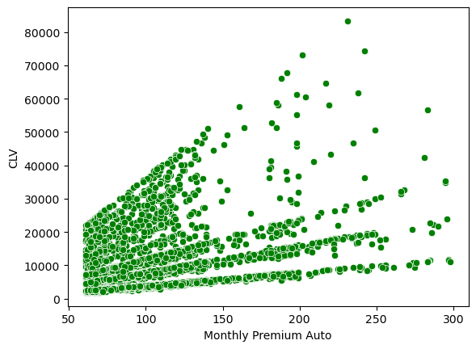

```python
sns.scatterplot(x=df["Monthly Premium Auto"], y=df["CLV"], color='g')
plt.show()
```

## Months Since Last Claim

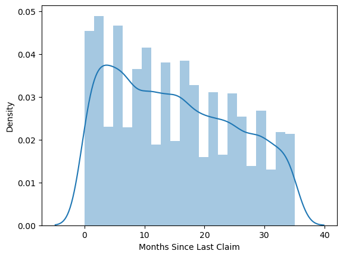

```python
sns.distplot(df['Months Since Last Claim'])
plt.show()
```

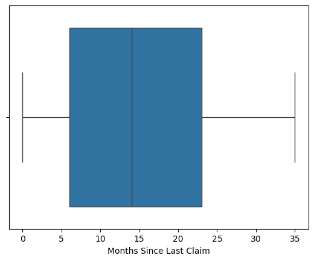

```python
sns.boxplot(x=df["Months Since Last Claim"])
plt.show()
```

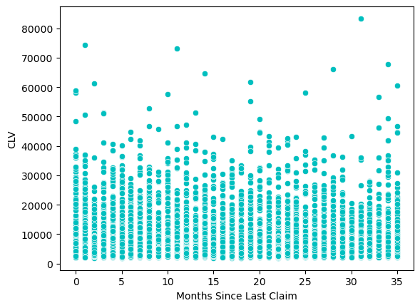

```python
sns.scatterplot(x=df["Months Since Last Claim"], y=df["CLV"], color='c')
plt.show()
```

There is no linear relatonship

## Months since policy inception

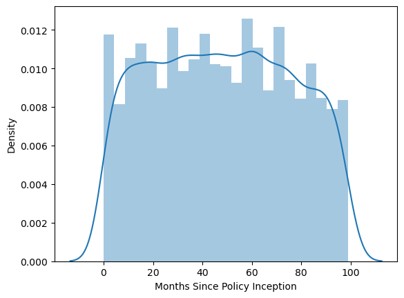

```python
sns.distplot(df['Months Since Policy Inception'])
plt.show()
```

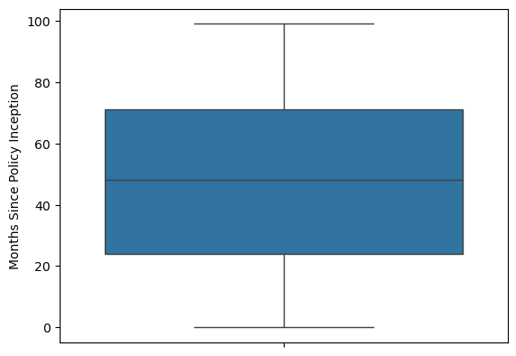

```python
sns.boxplot(df["Months Since Policy Inception"])
plt.show()
```

### Total claim amount

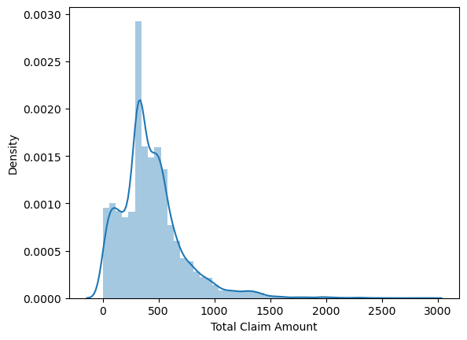

```python
sns.distplot(df['Total Claim Amount'])
plt.show()
```

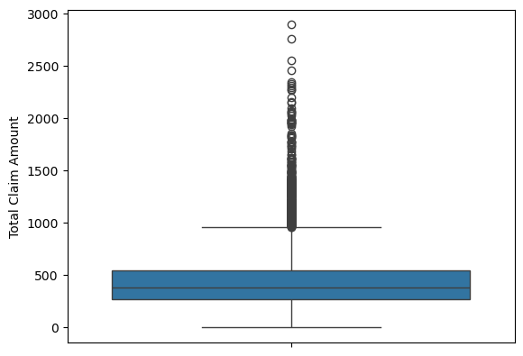

```python
sns.boxplot(df["Total Claim Amount"])
plt.show()
```

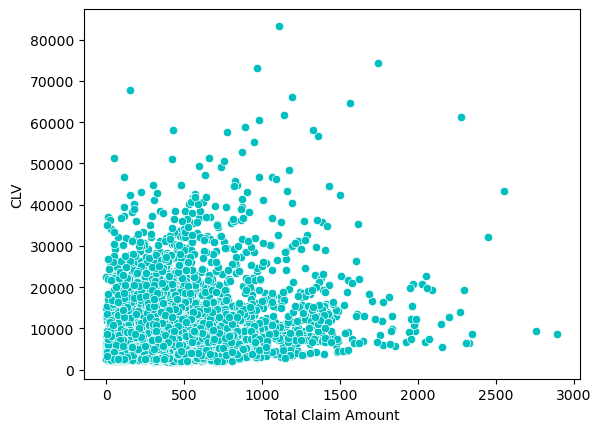

```python
sns.scatterplot(x=df["Total Claim Amount"],y=df["CLV"],color='c')
plt.show()
```

The monthly premium auto and income feature has multiple peak's so to remove those peaks we can apply any of the power transformation (SQUARE / CUBE)

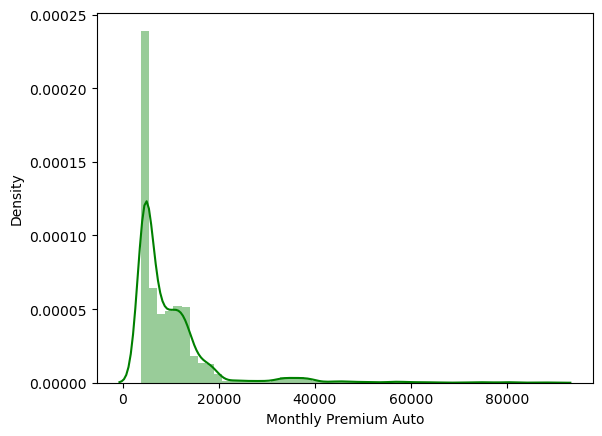

```python
sns.distplot(np.square(df["Monthly Premium Auto"]),color='g')
plt.show()
```

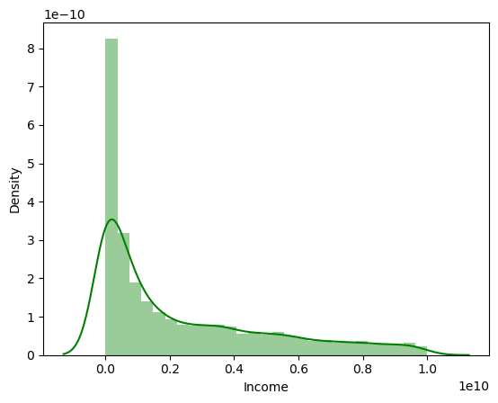

```python
sns.distplot(np.square(df["Income"]),color='g')
plt.show()
```

But as we can see that after the square transformation the data is getting heavily skewed, so we stick with the actual distribution again. We will just stick with the actual distribution of the feature in our model building.

## Categorical variables

```python
cat_cols = df.select_dtypes(include="object")
```

```python
no_col = df[["Number of Open Complaints","Number of Policies"]]
```

```python
cat_cols = pd.concat([cat_cols,no_col],axis=1)
```

```python
cat_cols.head()
```

|  | Customer | State | Response | Coverage | Education | Effective To Date | EmploymentStatus | Gender | Location Code | Marital Status | Policy Type | Policy | Renew Offer Type | Sales Channel | Vehicle Class | Vehicle Size | Number of Open Complaints | Number of Policies |
| --- | --- | --- | --- | --- | --- | --- | --- | --- | --- | --- | --- | --- | --- | --- | --- | --- | --- | --- |
| 0 | BU79786 | Washington | No | Basic | Bachelor | 2/24/11 | Employed | F | Suburban | Married | Corporate Auto | Corporate L3 | Offer1 | Agent | Two-Door Car | Medsize | 0 | 1 |
| 1 | QZ44356 | Arizona | No | Extended | Bachelor | 1/31/11 | Unemployed | F | Suburban | Single | Personal Auto | Personal L3 | Offer3 | Agent | Four-Door Car | Medsize | 0 | 8 |
| 2 | AI49188 | Nevada | No | Premium | Bachelor | 2/19/11 | Employed | F | Suburban | Married | Personal Auto | Personal L3 | Offer1 | Agent | Two-Door Car | Medsize | 0 | 2 |
| 3 | WW63253 | California | No | Basic | Bachelor | 1/20/11 | Unemployed | M | Suburban | Married | Corporate Auto | Corporate L2 | Offer1 | Call Center | SUV | Medsize | 0 | 7 |
| 4 | HB64268 | Washington | No | Basic | Bachelor | 3/2/2011 | Employed | M | Rural | Single | Personal Auto | Personal L1 | Offer1 | Agent | Four-Door Car | Medsize | 0 | 1 |

```python
cat_cols.drop("Effective To Date",axis=1,inplace=True)
```

```python
cat_cols.columns
```

```
Index(['Customer', 'State', 'Response', 'Coverage', 'Education',
       'EmploymentStatus', 'Gender', 'Location Code', 'Marital Status',
       'Policy Type', 'Policy', 'Renew Offer Type', 'Sales Channel',
       'Vehicle Class', 'Vehicle Size', 'Number of Open Complaints',
       'Number of Policies'],
      dtype='object')
```

```python
for i in cat_cols:
    print("Unique values in",str(i),"is",df[i].nunique())
    print(df[i].value_counts())
    print("-----------------------------------------")
```

```
Unique values in Customer is 9134
BU79786    1
PU81096    1
CO75086    1
WW52683    1
XO38850    1
          ..
HS14476    1
YL91587    1
CT18212    1
EW35231    1
Y167826    1
Name: Customer, Length: 9134, dtype: int64
-----------------------------------------
Unique values in State is 5
California    3150
Oregon        2601
Arizona       1703
Nevada         882
Washington     798
Name: State, dtype: int64
-----------------------------------------
Unique values in Response is 2
No     7826
Yes    1308
Name: Response, dtype: int64
-----------------------------------------
Unique values in Coverage is 3
Basic       5568
Extended    2742
Premium      824
Name: Coverage, dtype: int64
-----------------------------------------
Unique values in Education is 5
Bachelor                2748
College                 2681
High School or Below    2622
Master                   741
Doctor                   342
Name: Education, dtype: int64
```

[output cut: 79 more lines]

```
5      56
Name: Number of Open Complaints, dtype: int64
-----------------------------------------
Unique values in Number of Policies is 9
1    3251
2    2294
3    1168
7     433
9     416
4     409
5     407
8     384
6     372
Name: Number of Policies, dtype: int64
-----------------------------------------
```

Customer column which is the id has unique values for all records so it can be removed for model building as it adds no significance

### State

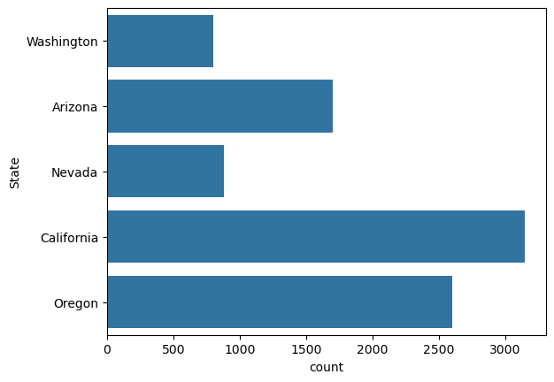

```python
sns.countplot(df["State"])
plt.show()
```

Most number of people are residing in california

### Response

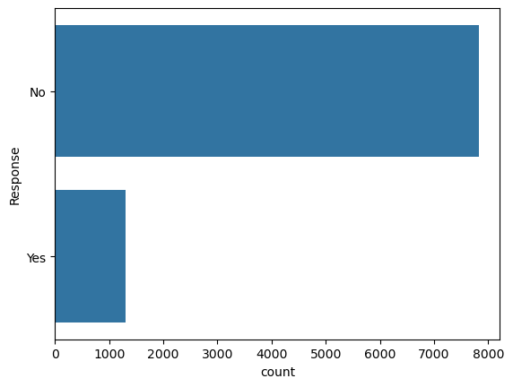

```python
sns.countplot(df["Response"])
plt.show()
```

Its seems that less then 1400 customers have responded to the marketing calls

### coverage

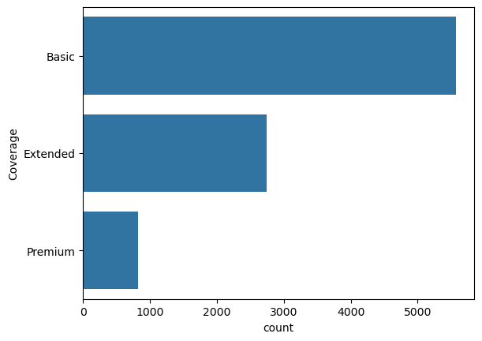

```python
sns.countplot(df["Coverage"])
plt.show()
```

### Education

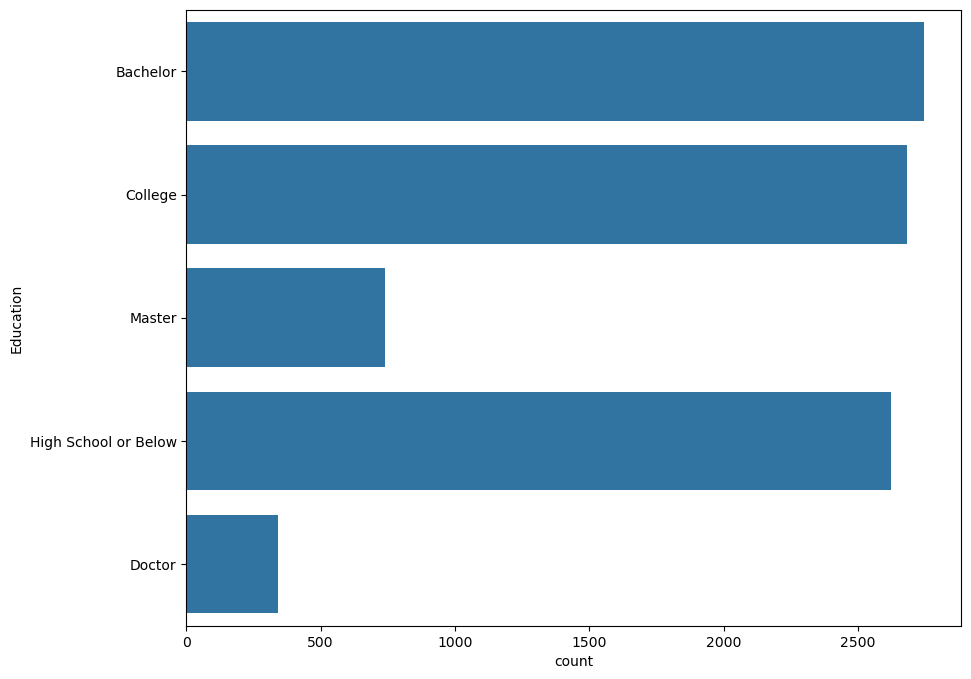

```python
plt.figure(figsize=(10,8))
sns.countplot(df["Education"])
plt.show()
```

### EmploymentStatus

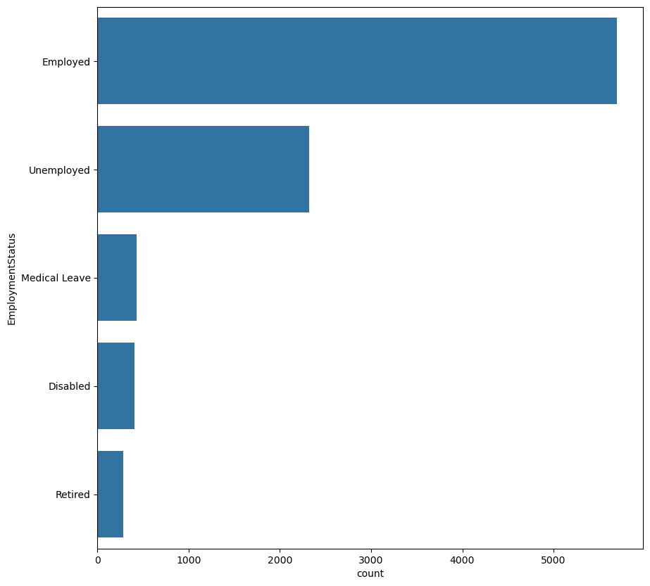

```python
plt.figure(figsize=(10,10))
sns.countplot(df["EmploymentStatus"])
plt.show()
```

```python
df["EmploymentStatus"].value_counts(normalize=True)*100
```

```
Employed         62.382308
Unemployed       25.366762
Medical Leave     4.729582
Disabled          4.433983
Retired           3.087366
Name: EmploymentStatus, dtype: float64
```

Around 62.38% of the customers are employed

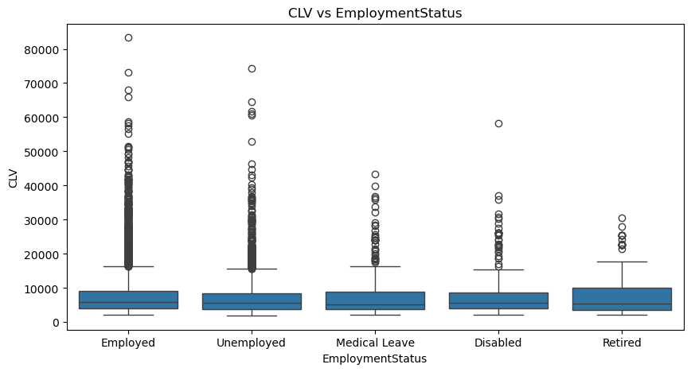

```python
plt.figure(figsize=(10,5))
sns.boxplot(x=df['EmploymentStatus'],y=df['CLV'])
plt.title("CLV vs EmploymentStatus")
# plt.savefig("bi1.png")
plt.show()
```

## Gender

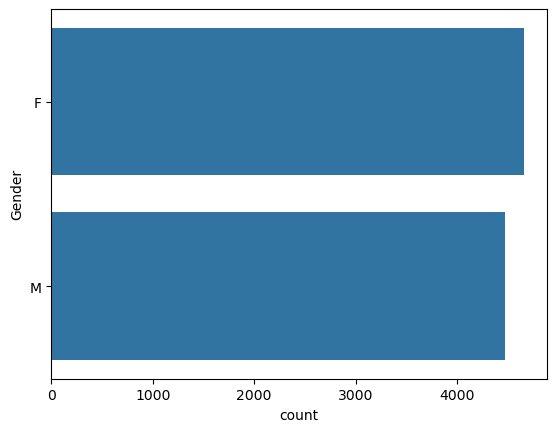

```python
sns.countplot(df["Gender"])
plt.show()
```

### Location code

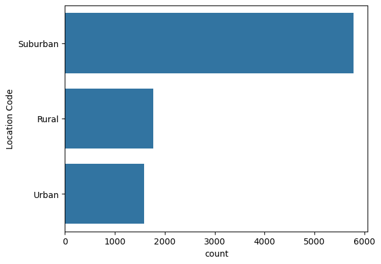

```python
sns.countplot(df["Location Code"])
plt.savefig("location.png")
plt.show()
```

### Marital Status

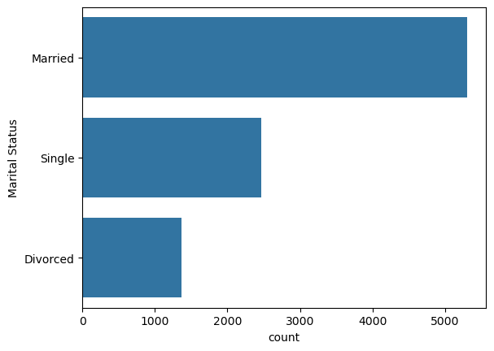

```python
sns.countplot(df["Marital Status"])
plt.show()
```

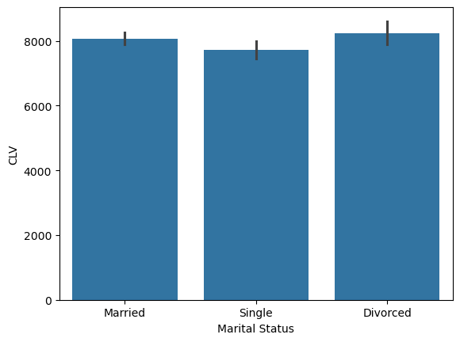

```python
sns.barplot(x=df["Marital Status"],y=df["CLV"])
plt.show()
```

### Policy Type

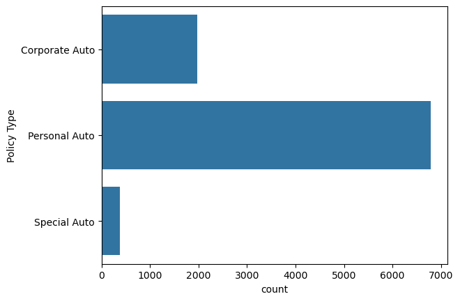

```python
sns.countplot(df["Policy Type"])
plt.show()
```